# Sample

Manh Ha Nguyen

2023-11-15

# Import lib

```r
library(tidyverse)
```

```r
library(mapview)
library(leaflet)
library(sf)
```

# Import data

```r
nsw_fuel <- read.csv("nsw_fuelprices_2022-12-11.csv")
nt_fuel <- read.csv("nt_fuelprices_2022-12-11.csv")
qld_fuel <- read.csv("qld_fuelprices_2022-12-11.csv")
sa_fuel <- read.csv("sa_fuelprices_2022-12-11.csv")
tas_fuel <- read.csv("tas_fuelprices_2022-12-11.csv")
```

# All function

## Plot gas station on map

- Ensure columns correctly named long, lat, brand
- Need further adjustment as station may sell many fuels type

```r
plot_points_on_map <- function(df, fueltype) {
  # Filter the data by fuel type
  df <- df[df$fueltype == fueltype, ]

  # Convert lat and long to spatial points
  points_sdf = st_as_sf(df, coords = c("long", "lat"), crs = 4326)

  # Plot the data
  mapview(points_sdf, zcol = "price", label = points_sdf$brand)
}
```

## Average fuel type price for given postcode

- Ensure postcode, fueltype, price correctly named

```r
avg_fuel_price <- function(df, fueltype, postcode) {
  # Filter the data by fuel type
  df <- df[df$fueltype == fueltype, ]

  # Filter the data by postcode
  df <- df[df$postcode == postcode, ]

  # Calculate the average price
  avg_price <- mean(df$price)

  # Return the average price
  return(avg_price)
}

avg_fuel_price(nsw_fuel, "U91", 2450)
```

```
## [1] NaN
```

## Find closet gas station given a coordinates

- Ensure long, lat, fueltype columns correctly named

```r
find_closest_gas_station <- function(df, fueltype, lat, long) {
  # Filter the data by fuel type
  df <- df[df$fueltype == fueltype, ]

  # Convert lat and long to spatial points
  points_sdf = st_as_sf(df, coords = c("long", "lat"), crs = 4326)

  # Convert lat and long to spatial points
  point_sdf = st_as_sf(data.frame(long = long, lat = lat), coords = c("long", "lat"), crs = 4326)

  # Find the closest gas station
  closest_gas_station <- st_nearest_feature(point_sdf, points_sdf)

  # Return the closest gas station
  return(closest_gas_station)
}

station_code <- find_closest_gas_station(nsw_fuel, "U91", -30.28,153.12)
nsw_fuel[nsw_fuel$stationcode == station_code, ]
```

```
##   stationcode         brand                        name
## 1           1 Coles Express Coles Express Coffs Harbour
## 2           1 Coles Express Coles Express Coffs Harbour
## 3           1 Coles Express Coles Express Coffs Harbour
## 4           1 Coles Express Coles Express Coffs Harbour
## 5           1 Coles Express Coles Express Coffs Harbour
##                                             address       lat     long fueltype
## 1 208-212 Pacific Hwy North, Coffs Harbour NSW 2450 -30.28608 153.1241       DL
## 2 208-212 Pacific Hwy North, Coffs Harbour NSW 2450 -30.28608 153.1241      E10
## 3 208-212 Pacific Hwy North, Coffs Harbour NSW 2450 -30.28608 153.1241      P95
## 4 208-212 Pacific Hwy North, Coffs Harbour NSW 2450 -30.28608 153.1241      P98
## 5 208-212 Pacific Hwy North, Coffs Harbour NSW 2450 -30.28608 153.1241      U91
##   fueltype_long price        collection_datetime collection_date
## 1        Diesel 231.9 2022-12-11 14:00:15.340765      2022-12-11
## 2    Ethanol 94 180.9 2022-12-11 14:00:15.340765      2022-12-11
## 3    Premium 95 197.9 2022-12-11 14:00:15.340765      2022-12-11
## 4    Premium 98 205.9 2022-12-11 14:00:15.340765      2022-12-11
## 5   Unleaded 91 182.9 2022-12-11 14:00:15.340765      2022-12-11
```

# Explore plotting

## NSW

Mutate postcode columns

```r
nsw_fuel <- nsw_fuel %>%
  mutate(postcode = str_extract(address, "\\b\\d{4}\\b"))
```

For all fuel

- further away from SYD, price tend to be higher?
- further in land, more expensive the fuel?
- along the coast, relatively equal?

```r
fueltype <- unique(nsw_fuel$fueltype)
plot_points_on_map(nsw_fuel,fueltype[4])
```

[interactive chart not shown]

Fuel type vs price

- Reccommend using EV consistently cheaper than fossil fuel

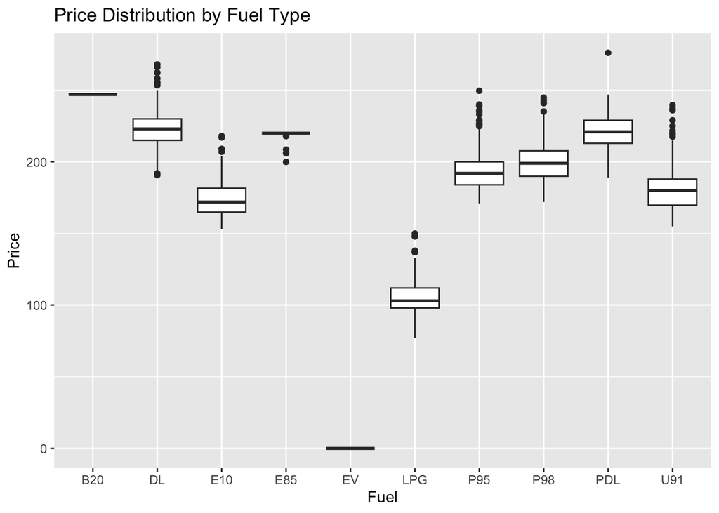

```r
ggplot(nsw_fuel, aes(x=fueltype, y=price)) +
  geom_boxplot() +
  labs(title="Price Distribution by Fuel Type", x="Fuel", y="Price")
```

Price Distribution by Brand for a type of fuel

- Observe that even for same type of fuel, and brand there can be variations between location

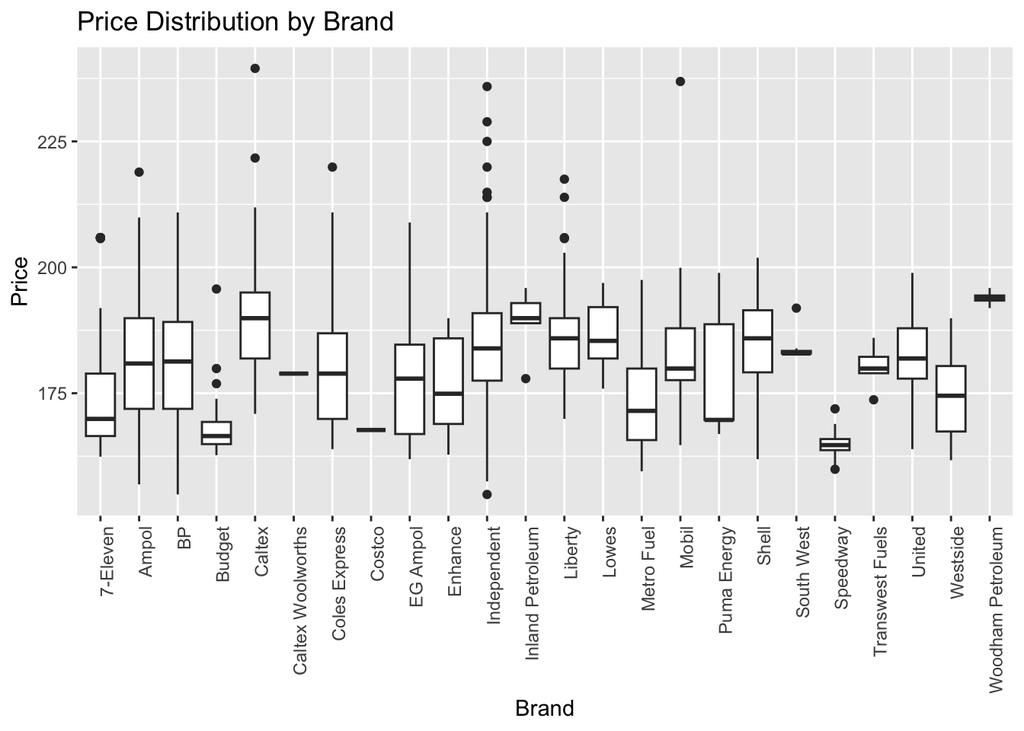

```r
# Combustion fuel price distribution  by brand
nsw_fuel %>%
  filter(fueltype != "EV") %>%   # remove EV as price is fixed
  filter(fueltype == "U91") %>%  # change fuel type
  ggplot(aes(x=brand, y=price)) +
  geom_boxplot() +
  theme(axis.text.x = element_text(angle = 90, hjust = 1)) +
  labs(title="Price Distribution by Brand", x="Brand", y="Price")
```

Fuel Type Popularity

- Variations of petroleum are the most popular

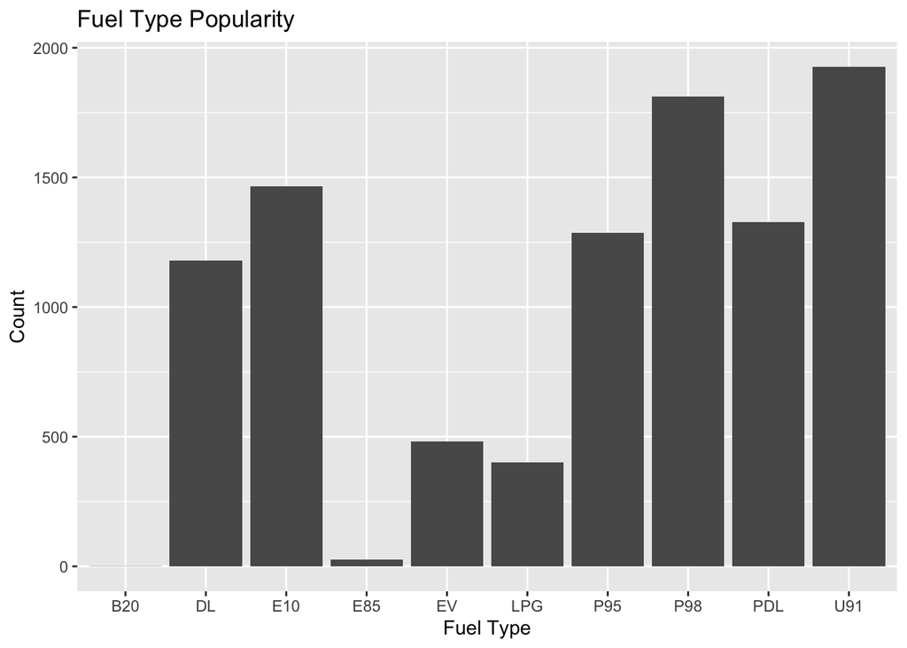

```r
# Fuel Type Popularity
ggplot(nsw_fuel, aes(x=fueltype)) +
  geom_bar() +
  labs(title="Fuel Type Popularity", x="Fuel Type", y="Count")
```

How far do you have to travel on average to fill up your car???

- Consider population density of each postcode to determine the weight of each postcode??
- Randomly distributed a corresponding number of representative points in each postcode???
- Calculate average distance from each point to the nearest gas station???
- Consider the number of gas station in each postcode???
- Problem: how to map postcode border??? + density within each postcode can fluctuate btw sections???

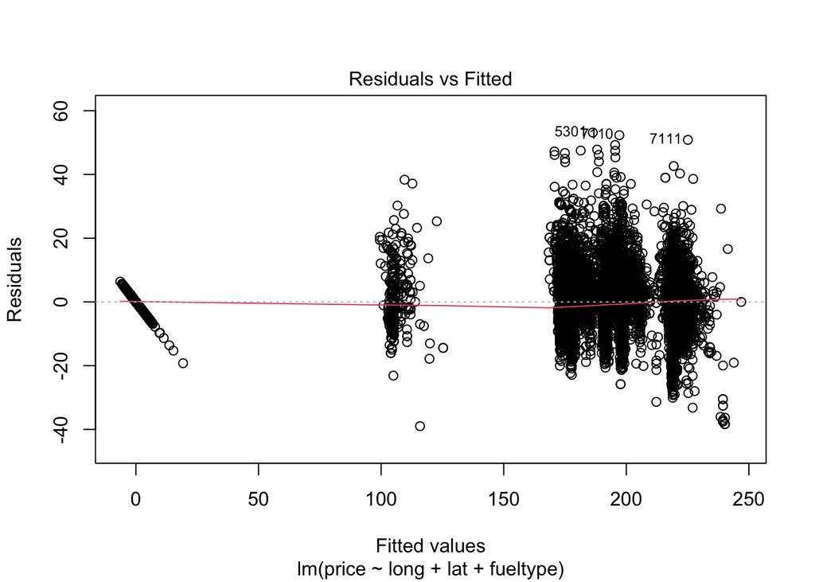

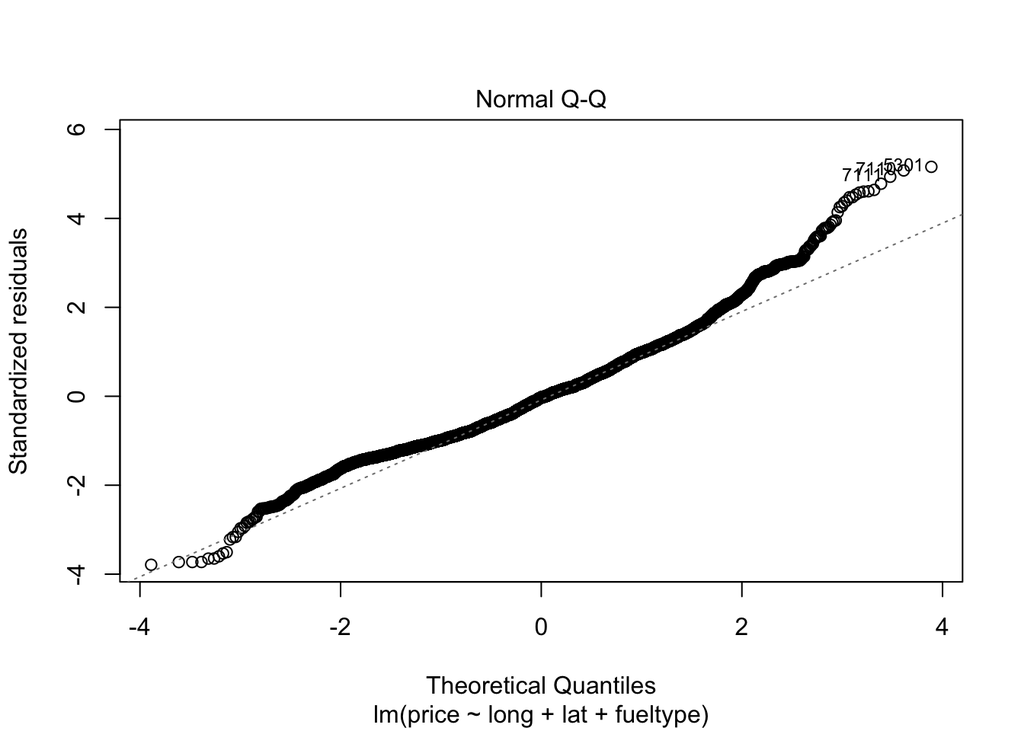

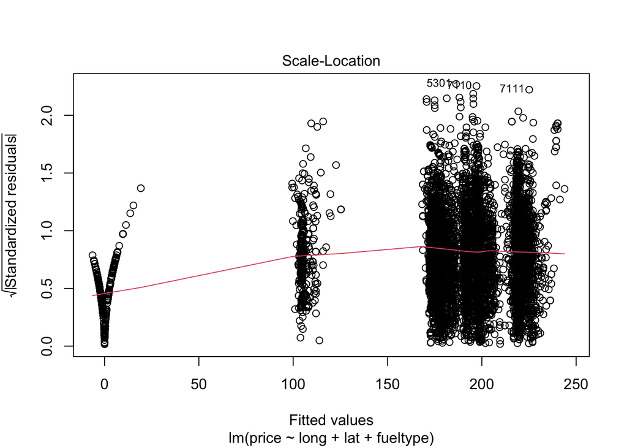

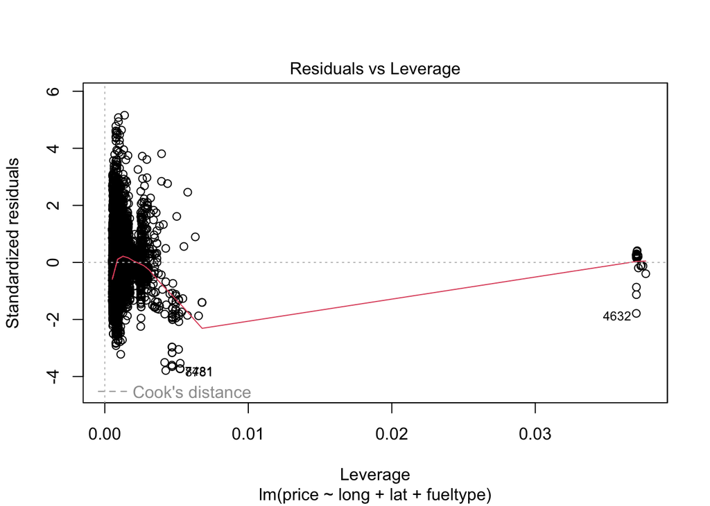

```r
# linear regression to fit price ~ long lat fueltype
nsw_model_parallel <- lm(price ~ long+lat+fueltype, data = nsw_fuel)
plot(nsw_model_parallel)
```

```r
summary(nsw_model_parallel)
```

```
##
## Call:
## lm(formula = price ~ long + lat + fueltype, data = nsw_fuel)
##
## Residuals:
##     Min      1Q  Median      3Q     Max
## -38.972  -7.757  -0.308   6.053  53.143
##
## Coefficients:
##               Estimate Std. Error t value Pr(>|t|)
## (Intercept)  586.55138   15.58970  37.624  < 2e-16 ***
## long          -1.76702    0.06821 -25.905  < 2e-16 ***
## lat            2.13912    0.07197  29.721  < 2e-16 ***
## fueltypeDL   -28.79444   10.31234  -2.792  0.00524 **
## fueltypeE10  -74.03322   10.31099  -7.180 7.47e-13 ***
## fueltypeE85  -30.02331   10.49661  -2.860  0.00424 **
## fueltypeEV  -249.02071   10.31830 -24.134  < 2e-16 ***
## fueltypeLPG -142.90126   10.32044 -13.846  < 2e-16 ***
## fueltypeP95  -55.96208   10.31161  -5.427 5.86e-08 ***
## fueltypeP98  -49.25133   10.31041  -4.777 1.81e-06 ***
## fueltypePDL  -28.00246   10.31140  -2.716  0.00663 **
## fueltypeU91  -69.73160   10.31036  -6.763 1.43e-11 ***
## ---
## Signif. codes:  0 '***' 0.001 '**' 0.01 '*' 0.05 '.' 0.1 ' ' 1
##
## Residual standard error: 10.31 on 9897 degrees of freedom
## Multiple R-squared:  0.9564, Adjusted R-squared:  0.9563
## F-statistic: 1.972e+04 on 11 and 9897 DF,  p-value: < 2.2e-16
```

```r
nsw_model_seperate <- lm(price ~ long*lat*fueltype, data = nsw_fuel)
nsw_model_seperate.step <- step(nsw_model_seperate, direction = "both")
```

```
## Start:  AIC=45743.95
## price ~ long * lat * fueltype
##
##                     Df Sum of Sq    RSS   AIC
## <none>                           994639 45744
## - long:lat:fueltype  8    2539.7 997179 45753
```

```r
summary(nsw_model_seperate.step)
```

```
##
## Call:
## lm(formula = price ~ long * lat * fueltype, data = nsw_fuel)
##
## Residuals:
##     Min      1Q  Median      3Q     Max
## -41.434  -7.358  -0.152   5.476  54.455
##
## Coefficients: (3 not defined because of singularities)
##                        Estimate Std. Error t value Pr(>|t|)
## (Intercept)          -1.960e+03  2.900e+02  -6.757 1.49e-11 ***
## long                  1.518e+01  1.917e+00   7.919 2.66e-15 ***
## lat                  -7.678e+01  8.686e+00  -8.839  < 2e-16 ***
## fueltypeDL            3.320e+02  4.190e+02   0.792 0.428098
## fueltypeE10          -7.778e+02  6.450e+02  -1.206 0.227905
## fueltypeE85          -3.921e+02  7.036e+03  -0.056 0.955558
## fueltypeEV            1.960e+03  7.392e+02   2.652 0.008025 **
## fueltypeLPG           3.928e+02  8.148e+02   0.482 0.629762
## fueltypeP95          -1.388e+02  4.865e+02  -0.285 0.775401
## fueltypeP98          -7.287e+02  4.503e+02  -1.618 0.105649
## fueltypePDL          -2.544e+02  5.360e+02  -0.475 0.635041
## fueltypeU91          -7.122e+01  1.004e+01  -7.092 1.41e-12 ***
## long:lat              5.250e-01  5.747e-02   9.136  < 2e-16 ***
## long:fueltypeDL      -2.555e+00  2.772e+00  -0.922 0.356730
## long:fueltypeE10      4.644e+00  4.251e+00   1.092 0.274642
## long:fueltypeE85      1.809e+00  4.613e+01   0.039 0.968720
## long:fueltypeEV      -1.518e+01  4.865e+00  -3.120 0.001815 **
## long:fueltypeLPG     -3.311e+00  5.391e+00  -0.614 0.539119
## long:fueltypeP95      5.399e-01  3.215e+00   0.168 0.866617
## long:fueltypeP98      4.368e+00  2.975e+00   1.468 0.142074
## long:fueltypePDL      1.292e+00  3.541e+00   0.365 0.715250
## long:fueltypeU91             NA         NA      NA       NA
## lat:fueltypeDL        1.731e+01  1.261e+01   1.372 0.169975
## lat:fueltypeE10      -2.440e+01  1.908e+01  -1.279 0.200904
## lat:fueltypeE85       7.524e-01  2.018e+02   0.004 0.997026
## lat:fueltypeEV        7.678e+01  2.198e+01   3.493 0.000479 ***
## lat:fueltypeLPG       1.830e+01  2.402e+01   0.762 0.446076
## lat:fueltypeP95      -4.274e+00  1.470e+01  -0.291 0.771186
## lat:fueltypeP98      -1.938e+01  1.344e+01  -1.441 0.149475
## lat:fueltypePDL       1.315e+00  1.593e+01   0.083 0.934220
## lat:fueltypeU91              NA         NA      NA       NA
## long:lat:fueltypeDL  -1.195e-01  8.355e-02  -1.431 0.152573
## long:lat:fueltypeE10  1.613e-01  1.258e-01   1.282 0.199839
## long:lat:fueltypeE85 -2.243e-02  1.323e+00  -0.017 0.986478
## long:lat:fueltypeEV  -5.250e-01  1.448e-01  -3.626 0.000290 ***
## long:lat:fueltypeLPG -1.140e-01  1.591e-01  -0.717 0.473465
## long:lat:fueltypeP95  2.831e-02  9.720e-02   0.291 0.770868
## long:lat:fueltypeP98  1.247e-01  8.890e-02   1.402 0.160870
## long:lat:fueltypePDL -1.481e-02  1.053e-01  -0.141 0.888188
## long:lat:fueltypeU91         NA         NA      NA       NA
## ---
## Signif. codes:  0 '***' 0.001 '**' 0.01 '*' 0.05 '.' 0.1 ' ' 1
##
## Residual standard error: 10.04 on 9872 degrees of freedom
## Multiple R-squared:  0.9587, Adjusted R-squared:  0.9586
## F-statistic:  6370 on 36 and 9872 DF,  p-value: < 2.2e-16
```

```r
BIC(nsw_model_parallel,nsw_model_seperate.step, nsw_model_seperate)
```

```
##                         df      BIC
## nsw_model_parallel      13 74460.76
## nsw_model_seperate.step 38 74140.12
## nsw_model_seperate      38 74140.12
```